# Statistical Inference - Week 4 Course Project - Part 1

Sanjay Lonkar

14 Jun 2018

## Overview

This assignment is Part 1 of Statistical Inference - Week 4 course project. Goal of this assignment is to perform A simulation exercise with following objectives:

In this project you will investigate the exponential distribution in R and compare it with the Central Limit Theorem. The exponential distribution can be simulated in R with rexp (n, lambda) where lambda is the rate parameter. The mean of exponential distribution is 1/lambda and the standard deviation is also 1/lambda. Set lambda = 0.2 for all of the simulations. You will investigate the distribution of averages of 40 exponentials. Note that you will need to do a thousand simulations.

Illustrate via simulation and associated explanatory text the properties of the distribution of the mean of 40 exponentials. You should

### Set the given constants in R variables

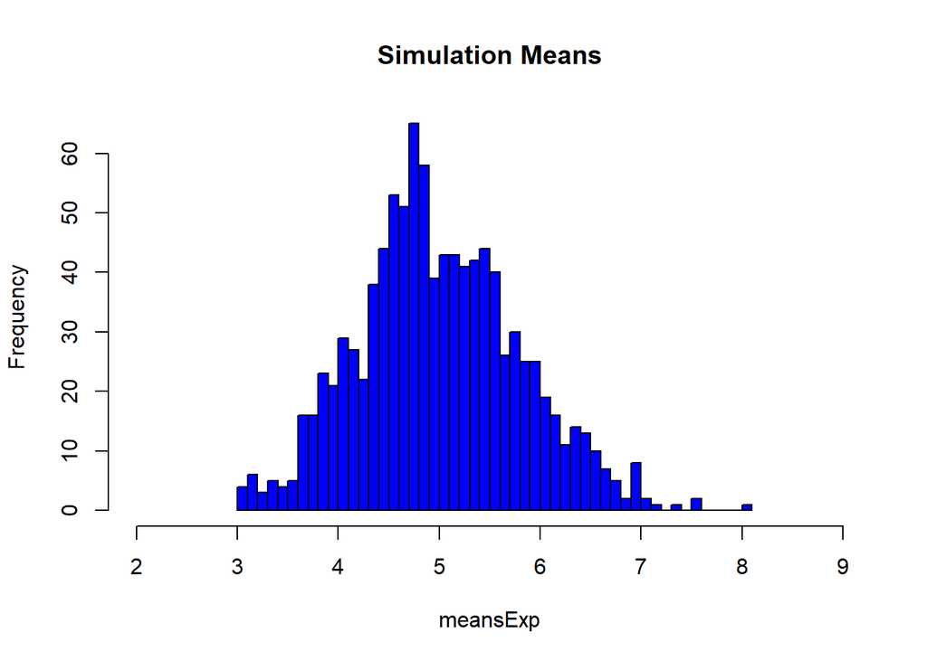

```r
set.seed(100)
lambda <- 0.2
n <- 40
simulations <- 1000

# Replicate to prepare simulations and calculate their mean
simulationsExp <- replicate (simulations, rexp(n, lambda))
meansExp <- apply (simulationsExp, 2, mean)

# Plot histogram
hist(meansExp, breaks = 40, xlim = c(2, 9), main = "Simulation Means", col = "blue")
```

### 1. Show the sample mean and compare it to the theoretical mean of the distribution

```r
sampleMean <- mean(meansExp)
theoreticalMean <- 1 / lambda

print(paste("Sample Mean of simulated data is", sampleMean, " while Theoretical Mean of same data is", theoreticalMean))
```

```
## [1] "Sample Mean of simulated data is 4.9997019268744  while Theoretical Mean of same data is 5"
```

```r
print(paste("Difference between these two is just", (theoreticalMean - sampleMean), "It indicates that Sample Mean and Theoretical Means are preety close."))
```

```
## [1] "Difference between these two is just 0.000298073125599707 It indicates that Sample Mean and Theoretical Means are preety close."
```

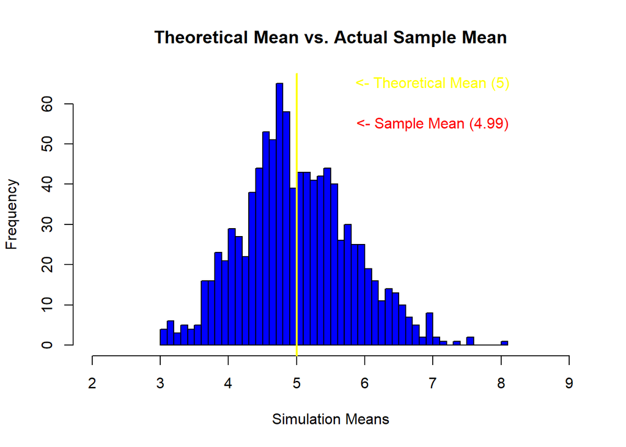

```r
# Show above in a plot
hist (meansExp, breaks = 40, xlim = c (2, 9), main = "Theoretical Mean vs. Actual Sample Mean", xlab = "Simulation Means", col="blue")

# plot a vertical red line at the mean of the sample means
abline (v = sampleMean, lwd = "2", col = "red")
abline (v = theoreticalMean, lwd = "2", col = "yellow")
text (x = 7, y = 55, "<- Sample Mean (4.99)", col = "red", lwd = 4)
text (x = 7, y = 65, "<- Theoretical Mean (5)", col = "yellow", lwd = 4)
```

### 2. Show how variable the sample is (via variance) and compare it to the theoretical variance of the distribution

```r
theoreticalVar <- round (((1/lambda)/sqrt(n))^2 ,4)
simulatedVar <- round (sd(meansExp)^2 ,4)

print(paste("Simulated variance of this data is", simulatedVar, " while Theoretical variance of same data is", theoreticalVar))
```

```
## [1] "Simulated variance of this data is 0.6432  while Theoretical variance of same data is 0.625"
```

```r
print(paste("Difference between these two is just", (theoreticalVar - simulatedVar), "It indicates that Sample Variance and Theoretical Variance are preety close."))
```

```
## [1] "Difference between these two is just -0.0182 It indicates that Sample Variance and Theoretical Variance are preety close."
```

### 3. Show that the distribution is approximately normal

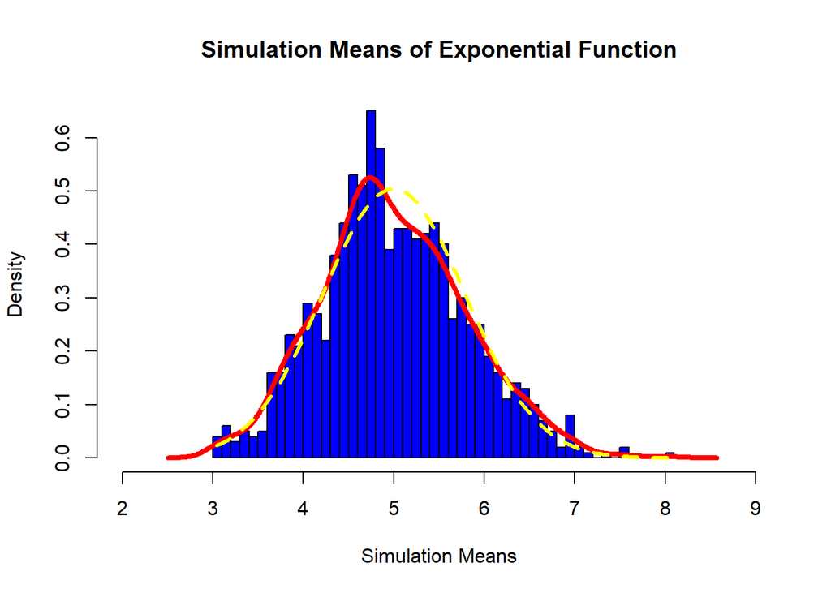

```r
#General Plot with ditribution curve drawn
hist (meansExp, prob = TRUE, col = "blue", main="Simulation Means of Exponential Function", breaks = 40, xlim = c (2, 9), xlab = "Simulation Means")
lines (density (meansExp), lwd = 4, col = "red")

# Normal distribution line creation
x <- seq (min (meansExp), max (meansExp), length =2*n)
y <- dnorm (x, mean = 1 / lambda, sd = sqrt (((1/lambda)/sqrt(n))^2))
lines(x, y, pch = 22, col = "yellow", lwd = 3, lty = 2)
```

```r
print("Sample curve is red line and yellow dotted line is normal distribution. Both these are very close as one can see in the plot above.")
```

```
## [1] "Sample curve is red line and yellow dotted line is normal distribution. Both these are very close as one can see in the plot above."
```